# R Introduction

2015-09-24

## Outline

- Overview
- Data Structures
- Function
- Control Flow
- Miscellaneous
- References

## Overview

## What is R

- A free software environment for statistical computing and graphics
- An open source version of S language
- An interpreted language builded with C, C++, Fortran and R
- A general-purpose scripting language
- Multi-paradigm
  - Procedual, Object-Oriented and Functional

## Why R

- It's free
- High-level functions/packages for analytic tasks
- Most popular analytic tool
- Communities with Statisticians, Analysts and Data Scientists
- To communicated with analyst / engineer
- Intergrated environment for reproducible research

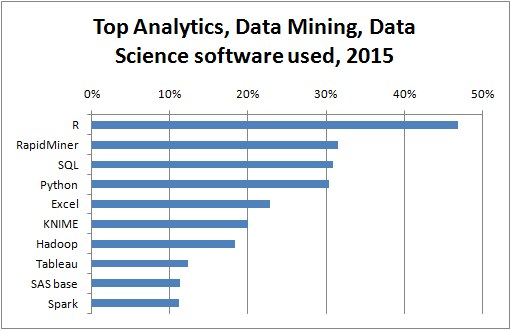

[KDnuggets Poll 2015](http://www.kdnuggets.com/2015/05/poll-r-rapidminer-python-big-data-spark.html)

## Installation

You can use R in various environments:

- [Windows](https://www.youtube.com/watch?v=Ohnk9hcxf9M)  
  Download [base](https://cran.rstudio.com/bin/windows/base/) and [Rtools](https://cran.rstudio.com/bin/windows/Rtools/)(optional) then install
- [Mac](https://www.youtube.com/watch?v=uxuuWXU-7UQ)  
  Download [R-x.x.x.pkg](https://cran.rstudio.com/bin/macosx/) and install
- Linux  
  You may use apt-get or yum to install your R environment
  - [Ubuntu](https://cran.r-project.org/bin/linux/ubuntu/README)
  - [Red Hat](https://cran.r-project.org/bin/linux/redhat/README)

Using Linux or Mac may save your time with encoding issue.

## Rstudio

[Rstudio](https://www.rstudio.com/) is a powerful IDE that make you more confortable with R.

- [Rstudio Desktop](https://www.rstudio.com/products/rstudio/download/)

  A Rstudio IDE on your local machine. Download the installer of your OS and install it. [Here](https://www.youtube.com/watch?v=bM7Sfz-LADM) is a video from [Roger Peng](http://www.biostat.jhsph.edu/~rpeng/) about how to install RStudio on mac
- [Rstudio Server](https://www.rstudio.com/products/rstudio/download-server/)

  A Rstudio IDE Server on Linux platform. Download the installer and follow the instruction.

## How to get help

- `?`: Access ducument in R console
- `??`: Search the halp system
- google with appropriate keyword. For example:
  - R {package name}
  - R {algorithm name}
- Forum
  - [Taiwan R user Group](http://www.meetup.com/Taiwan-R/)  
    A free R/data analysis user group in Taiwan
  - [Stack Overflow](http://stackoverflow.com/questions/tagged/r)  
    A question and answer site for programmers
  - [PTT R_Language board](https://www.ptt.cc/bbs/R_Language/index.html)  
    A bbs forum for R in Taiwan

## Assignment

You can use `<-` or `=` to assign a value to a variable.

```r
x <- 9.8
y = 689
z = x * 2 + y - (5 / 3^2)
z
```

```
## [1] 708.0444
```

Most [Programming Style Goude](http://adv-r.had.co.nz/Style.html) would recommend using `<-` for assignment.

Please visit [here](http://adv-r.had.co.nz/Vocabulary.html) for more vocabulary in R.

## Working Environment

Using `getwd`/`setwd` to get/set your working directory.

```r
wd = getwd()
setwd("img")
getwd()
```

```
## [1] "/home/mansun/github/r_intro/img"
```

```r
setwd(wd)
getwd()
```

```
## [1] "/home/mansun/github/r_intro"
```

If you [using Projects](https://support.rstudio.com/hc/en-us/articles/200526207-Using-Projects), RStudio will change working directory for you automatically.

## Exercise: Hello R/RStudio

Let's have fun with R/RStudio

[figure not shown]

## Data Structures

## Basic Data Structure

Vector, Matrix, Array, List and Data frame are the most basic data structure in R. These data structures can be mapped into a table according to:

- dimension
- Homogeneous or Heterogeneous of data type

|  | Homogeneous | Heterogeneous |
| --- | --- | --- |
| 1d | Atomic vector | List |
| 2d | Matrix | Data frame |
| nd | Array |  |

## Vector

Vector is a basic data structure in R. A scalar is a vector of length 1.

```r
v1 <- c(1:10)
v1
```

```
##  [1]  1  2  3  4  5  6  7  8  9 10
```

```r
is.vector(v1)
```

```
## [1] TRUE
```

```r
length(v1)
```

```
## [1] 10
```

```r
s1 <- 2
s1
```

```
## [1] 2
```

```r
is.vector(s1)
```

```
## [1] TRUE
```

```r
length(s1)
```

```
## [1] 1
```

## Type of Vector

Vector can contains several kinds of type. Type describes how the object is stored in memory. Elements in a vector will convert into looser types.

```r
logical_v = c(TRUE, FALSE, T, F)
typeof(logical_v)
```

```
## [1] "logical"
```

```r
int_v <- c(2L, 3L, 4L)
typeof(int_v)
```

```
## [1] "integer"
```

```r
numeric_v <- c(2.5, 3, pi)
typeof(numeric_v)
```

```
## [1] "double"
```

```r
character_v = c("apple", "banana", 1)
typeof(character_v)
```

```
## [1] "character"
```

## Calculation with vector

Vectors can be calculated in the sense of [Array Programming](https://en.wikipedia.org/wiki/Array_programming).

```r
x <- 9.8
v1 <- 1:10
v1 * x
```

```
##  [1]  9.8 19.6 29.4 39.2 49.0 58.8 68.6 78.4 88.2 98.0
```

```r
v2 <- c(rep(2, 5), rep(3,5))
v2
```

```
##  [1] 2 2 2 2 2 3 3 3 3 3
```

```r
v1 + v2
```

```
##  [1]  3  4  5  6  7  9 10 11 12 13
```

## Recycle

If you calculate tow vectors with different length, the shorter vector will be recycled with the longer vector.

```r
v3 <- c(2, 3)
v1^v3
```

```
##  [1]    1    8    9   64   25  216   49  512   81 1000
```

```r
v4 <- c(2, 3, 4)
v1*v4
```

```
##  [1]  2  6 12  8 15 24 14 24 36 20
```

## Factor

A factor is a vector that can contain only predefined values, and is used to store categorical data. Factors are widely used in various statically function(Ex: Regression, graphics, table) in R.

```r
gender <- c("Male", "Female", "Female", "Male")
gender <- factor(gender)
gender
```

```
## [1] Male   Female Female Male
## Levels: Female Male
```

```r
as.integer(gender)
```

```
## [1] 2 1 1 2
```

```r
as.character(gender)
```

```
## [1] "Male"   "Female" "Female" "Male"
```

## Named vector

A vector can have a name attribute.

```r
v5 <- c(1.2, 5, 8 , 12, 4.3, TRUE)
v5
```

```
## [1]  1.2  5.0  8.0 12.0  4.3  1.0
```

```r
names(v5) <- c("a", "b", "c", "d", "e", "f")
v5
```

```
##    a    b    c    d    e    f
##  1.2  5.0  8.0 12.0  4.3  1.0
```

```r
attributes(v5)
```

```
## $names
## [1] "a" "b" "c" "d" "e" "f"
```

## Subsetting: vector

you can subset a vector in various ways.

```r
v5[c(5, 2, 6)]
```

```
##   e   b   f
## 4.3 5.0 1.0
```

```r
v5[-c(1, 3)]
```

```
##    b    d    e    f
##  5.0 12.0  4.3  1.0
```

```r
v5[c("a", "f", "c")]
```

```
##   a   f   c
## 1.2 1.0 8.0
```

```r
v5[c(T, F, F, T, F, T)]
```

```
##    a    d    f
##  1.2 12.0  1.0
```

```r
v5[v5 >=7.5]
```

```
##  c  d
##  8 12
```

```r
v5[v5 == max(v5)]
```

```
##  d
## 12
```

## Matrix

Matrix is a 2-dimenstion array. You can have various [matrix operation in R](http://www.statmethods.net/advstats/matrix.html).

```r
x <- matrix(c(2,1,3,2), nrow = 2, ncol = 2)
rownames(x) <- c("a", "b")
colnames(x) <- c("x", "y")
```

```r
# eigenvalue and eigenvector
eigen(x)
```

```
## $values
## [1] 3.7320508 0.2679492
##
## $vectors
##           [,1]       [,2]
## [1,] 0.8660254 -0.8660254
## [2,] 0.5000000  0.5000000
```

```r
# matrix multiplication and transpose
x %*% t(x)
```

```
##    a b
## a 13 8
## b  8 5
```

## Subsetting: matrix

You can subset a matrix in various ways.

```r
x[1, ]
```

```
## x y
## 2 3
```

```r
x["b", ]
```

```
## x y
## 1 2
```

```r
x["a", 2]
```

```
## [1] 3
```

```r
x[2, 1:2]
```

```
## x y
## 1 2
```

```r
x[2, 2]
```

```
## [1] 2
```

```r
x["b", 2]
```

```
## [1] 2
```

## List

Elements in a list can be any kinds type and its length is arbitrary. Function `str` can help you investigate the structure of a nested list.

```r
li <- list(a = 1:10,
           b = c("apple", "banana"))
str(li)
```

```
## List of 2
##  $ a: int [1:10] 1 2 3 4 5 6 7 8 9 10
##  $ b: chr [1:2] "apple" "banana"
```

```r
li2 <- list(li = li,
            c = matrix(1:4, nrow = 2))
str(li2)
```

```
## List of 2
##  $ li:List of 2
##   ..$ a: int [1:10] 1 2 3 4 5 6 7 8 9 10
##   ..$ b: chr [1:2] "apple" "banana"
##  $ c : int [1:2, 1:2] 1 2 3 4
```

## Subsetting: list

You can subset a data frame in various ways.

```r
li2$li$a
```

```
##  [1]  1  2  3  4  5  6  7  8  9 10
```

```r
li2$c
```

```
##      [,1] [,2]
## [1,]    1    3
## [2,]    2    4
```

```r
li2[[1]][[2]]
```

```
## [1] "apple"  "banana"
```

```r
li2[["li"]][["b"]]
```

```
## [1] "apple"  "banana"
```

```r
li2[["li"]][["b"]][2]
```

```
## [1] "banana"
```

```r
li2$li[[1]]
```

```
##  [1]  1  2  3  4  5  6  7  8  9 10
```

## Exercise: options

There are a lot of global option in your R environment.

1. Please type `options()` to see what they are
2. Create a list names op which is equal to the output of options()
3. Use names(op) to see the names in op.
4. Extract the component in op that named `digits`

## Answer

```r
options()
```

```
## $add.smooth
## [1] TRUE
##
## $bitmapType
## [1] "cairo"
##
## $browser
## [1] "xdg-open"
##
## $browserNLdisabled
## [1] FALSE
##
## $CBoundsCheck
## [1] FALSE
##
## $check.bounds
## [1] FALSE
##
## $citation.bibtex.max
## [1] 1
##
## $continue
## [1] "+ "
##
## $contrasts
##         unordered           ordered
## "contr.treatment"      "contr.poly"
##
## $defaultPackages
## [1] "datasets"  "utils"     "grDevices" "graphics"  "stats"     "methods"
##
## $demo.ask
## [1] "default"
##
## $deparse.cutoff
## [1] 60
##
## $device
## function (width = 7, height = 7, ...)
## {
```

[output cut: 144 more lines]

```
##
## $useFancyQuotes
## [1] FALSE
##
## $verbose
## [1] FALSE
##
## $warn
## [1] 0
##
## $warning.length
## [1] 1000
##
## $width
## [1] 75
```

```r
op <- options()
names(op)
```

```
##  [1] "add.smooth"            "bitmapType"
##  [3] "browser"               "browserNLdisabled"
##  [5] "CBoundsCheck"          "check.bounds"
##  [7] "citation.bibtex.max"   "continue"
##  [9] "contrasts"             "defaultPackages"
## [11] "demo.ask"              "deparse.cutoff"
## [13] "device"                "device.ask.default"
## [15] "digits"                "dvipscmd"
## [17] "echo"                  "editor"
## [19] "encoding"              "example.ask"
## [21] "expressions"           "help.search.types"
## [23] "help.try.all.packages" "HTTPUserAgent"
## [25] "internet.info"         "keep.source"
## [27] "keep.source.pkgs"      "knitr.in.progress"
## [29] "locatorBell"           "mailer"
```

[output cut: 16 more lines]

```r
op$digits
```

```
## [1] 7
```

## Data Frame

Data frame is a 2-dimension data structure to deal with a table-like heterogeneous data.

```r
df <- data.frame(gender = c("male", "female", "female", "male"),
                 age = c(33, 18, 24, 26))
## Add new column in a data frame
df$city <- c("Taipei", "Taipei", "Hsinchu", "Taichung")
```

```r
df
```

```
##   gender age     city
## 1   male  33   Taipei
## 2 female  18   Taipei
## 3 female  24  Hsinchu
## 4   male  26 Taichung
```

```r
str(df)
```

```
## 'data.frame':    4 obs. of  3 variables:
##  $ gender: Factor w/ 2 levels "female","male": 2 1 1 2
##  $ age   : num  33 18 24 26
##  $ city  : Factor w/ 3 levels "Hsinchu","Taichung",..: 3 3 1 2
```

## Subsetting: data frame

You can subset a data frame in various ways.

```r
df[c(1, 3), "city"]
```

[output not shown]

```r
df[3, c("gender", "age")]
```

```
##   gender age
## 3 female  24
```

```r
df$gender[c(2,3)]
```

```
## [1] female female
## Levels: female male
```

```r
df[df$gender == "female", c(2, 3)]
```

```
##   age    city
## 2  18  Taipei
## 3  24 Hsinchu
```

## Exercise: data frame

[iris dataset](https://en.wikipedia.org/wiki/Iris_flower_data_set) is one of the most common dataset to be demo.

Use `data` to load default data set in R:

```r
data(iris)
```

Please try following tasks:

1. Create a data.frame named iris1 which the species is equal to **setosa**
2. Create a data.frame named iris2 which the Sepal.Length is larger than 6.
3. Create a data.frame named iris3 which only contains two columns, Sepal.Length and Sepal.Width.

## Answer

```r
data(iris)
iris1 <- iris[iris$Species == "setosa",]
iris2 <- iris[iris$Sepal.Length > 6,]
iris3 <- iris[, c("Sepal.Length", "Sepal.Width")]
```

## Recap: data structure

All data structures above are objects. They apply different methods and saved as different type internally.

| object | type | class |
| --- | --- | --- |
| c(1, 2.5, 3) | double | numeric |
| c("male", "female", "female", "male") | character | character |
| factor(c("male", "female", "female", "male")) | integer | factor |
| matrix(1:9, nrow = 3) | integer | matrix |
| list(a = 1:10, b = c("apple", "banana")) | list | list |
| data.frame(a = 1, b = "z") | list | data.frame |

## Beyond basic data structure

- Use [read.csv or read.table](https://stat.ethz.ch/R-manual/R-devel/library/utils/html/read.table.html) to read a csv file or tab-separated file into data.frame.
- Use [RODBC](https://cran.r-project.org/web/packages/RODBC/index.html), [RJDBC](https://cran.r-project.org/web/packages/RJDBC/index.html), [RMySQL](https://cran.r-project.org/web/packages/RMySQL/index.html) … to read data from database
- Use [jsonlite](https://cran.r-project.org/web/packages/jsonlite/index.html) or [rjson](https://cran.r-project.org/web/packages/rjson/index.html) to read a JSON file into list or data.frame.
- Use [yaml](http://cran.fhcrc.org/web/packages/yaml/index.html) to read a yaml file into list.
- Use [XML](https://cran.r-project.org/web/packages/XML/index.html) to parse XML/HTML.
- Use [cbind or rbind](https://stat.ethz.ch/R-manual/R-devel/library/base/html/cbind.html) to combine matrixs of data frames.
- Use [reshape2](https://cran.r-project.org/web/packages/reshape2/index.html) and [dplyr](https://cran.r-project.org/web/packages/dplyr/index.html) for merge, arrgegation, pivot and related data manipulation tasks.
- Use [data.table](http://mansunkuo.github.io/dsc2015_data.table/#1) for an enhanced version of data frame and total solution of ETL.

## Function

## Every operation is a function call

*To understand computations in R, two slogans are helpful:*

- *Everything that exists is an object.*
- *Everything that happens is a function call."*

*— John Chambers*

```r
`+`
```

```
## function (e1, e2)  .Primitive("+")
```

```r
`<-`
```

```
## .Primitive("<-")
```

```r
`[`
```

```
## .Primitive("[")
```

```r
`c`
```

```
## function (..., recursive = FALSE)  .Primitive("c")
```

## Some useful functions in R

```r
data(iris)  # Load default dataset in R
```

```r
mean(iris$Sepal.Length)
```

```
## [1] 5.843333
```

```r
sd(iris$Sepal.Length)
```

```
## [1] 0.8280661
```

```r
max(iris$Sepal.Length)
```

```
## [1] 7.9
```

```r
length(iris$Sepal.Length)
```

```
## [1] 150
```

```r
quantile(iris$Sepal.Length)
```

```
##   0%  25%  50%  75% 100%
##  4.3  5.1  5.8  6.4  7.9
```

```r
table(iris$Species)
```

```
##
##     setosa versicolor  virginica
##         50         50         50
```

## Some useful functions in R - 2

```r
summary(iris)
```

```
##   Sepal.Length    Sepal.Width     Petal.Length    Petal.Width
##  Min.   :4.300   Min.   :2.000   Min.   :1.000   Min.   :0.100
##  1st Qu.:5.100   1st Qu.:2.800   1st Qu.:1.600   1st Qu.:0.300
##  Median :5.800   Median :3.000   Median :4.350   Median :1.300
##  Mean   :5.843   Mean   :3.057   Mean   :3.758   Mean   :1.199
##  3rd Qu.:6.400   3rd Qu.:3.300   3rd Qu.:5.100   3rd Qu.:1.800
##  Max.   :7.900   Max.   :4.400   Max.   :6.900   Max.   :2.500
##        Species
##  setosa    :50
##  versicolor:50
##  virginica :50
##
##
##
```

## Function in R

A typical function in R may look like:

```r
f <- function(arg1, arg2, ...) {
    # Some magic happened
    return()    # return something
}
```

- If you don't use `return` to specify the return value, the return value will be the last expression inside the function.
- Call by value by default  
  send a copy of a object into a function and the input object won't change after execution without assignment
- [First class object](https://en.wikipedia.org/wiki/First-class_citizen)
  - Can be passed as arguments to other functions
  - Can be nested

## Exercise: Your first function

Here is a simple function that compute the mean of specific columns in a data.frame

```r
colmean <- function(df, cname) {
    out <- list(mean = mean(df[, cname]))
    return(out)
}
colmean(iris, "Sepal.Length")
```

```
## $mean
## [1] 5.843333
```

Please modify the function to return a list with both mean and standard deviation(sd)

## Answer

```r
colmean <- function(df, cname) {
    out <- list(mean = mean(df[, cname]),
                sd = sd(df[, cname]))
    return(out)
}
colmean(iris, "Sepal.Length")
```

```
## $mean
## [1] 5.843333
##
## $sd
## [1] 0.8280661
```

## Control Flow

## If

The basc structure of conditional execution in R is:

```r
if (an expression returns TRUE or FALSE) {
    # do something
} else if (another expression returns TRUE or FALSE) {
    # do something
} else {
    # do something
}
```

## An example

Here is a function to print different string respect to x and y.

```r
printer <- function(x, y = 0) {
    if (x > y) {
        print(sprintf("%s is great than %s", x, y))
    } else if (x < y) {
        print(sprintf("%s is less than %s", x, y))
    } else {
        print(sprintf("%s equals to %s", x, y))
    }
}
printer(3.6, 9.8)
```

```
## [1] "3.6 is less than 9.8"
```

```r
printer(3.6)    # take y = 0
```

```
## [1] "3.6 is great than 0"
```

## Loops in R

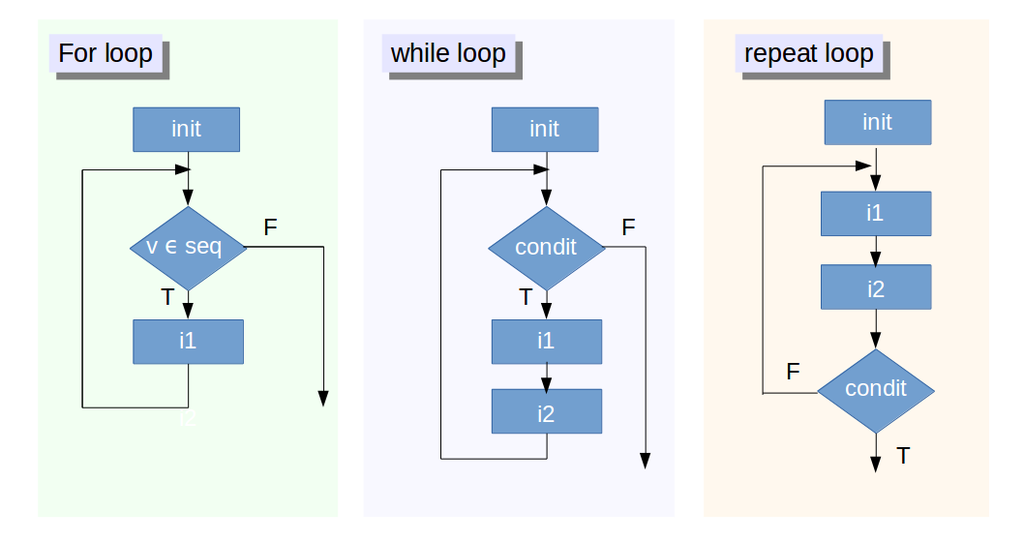

http://blog.datacamp.com/wp-content/uploads/2015/07/flowchart1.png

## For

You can use for loop with integer.

```r
# loop with integer
x <- c("a", "b", "c")
v <- numeric(length(x))
for (i in 1:length(x)) {
    v[i] <- i
}
v
```

```
## [1] 1 2 3
```

## Nested for loop

loops can be nested.

```r
# nested loop
m <- matrix(numeric(), nrow = 2, ncol = 2)
for (i in 1:nrow(m)) {
    for (j in 1:ncol(m)) {
        m[i, j] <- i * j
    }
}
m
```

```
##      [,1] [,2]
## [1,]    1    2
## [2,]    2    4
```

## Exercise: nested for loop

Please write a function that generate a n*n multiplication table with matrix

## Answer

```r
# nested loop
mtable <- function(n) {
    m <- matrix(numeric(), nrow = n, ncol = n)
    for (i in 1:nrow(m)) {
        for (j in 1:ncol(m)) {
            m[i, j] <- i * j
        }
    }
    m
}
mtable(3)
```

```
##      [,1] [,2] [,3]
## [1,]    1    2    3
## [2,]    2    4    6
## [3,]    3    6    9
```

## For loop with list and character vector

For loop can iterate over objects other than numeric vector.

```r
# loop with list
for (i in list(a = "a", b = 1:2)) {
    print(i)
}
```

```
## [1] "a"
## [1] 1 2
```

```r
# loop with character vector
for (i in c("a", "b", "c")) {
    print(i)
}
```

```
## [1] "a"
## [1] "b"
## [1] "c"
```

## Beyond for loop

- Loop in R is not very efficient. Use vectorized function insteded if you can.

```r
library(rbenchmark)
for_sum <- function(x) {
    out <- 0
    for (i in 1:length(x)) {
        out<- out + i
    }
    return(out)
}
benchmark(sum(as.numeric(1:1000000)), for_sum(as.numeric(1:1000000)))
```

```
##                           test replications elapsed relative user.self
## 2 for_sum(as.numeric(1:1e+06))          100  39.308   46.684    34.452
## 1     sum(as.numeric(1:1e+06))          100   0.842    1.000     0.704
##   sys.self user.child sys.child
## 2    0.010          0         0
## 1    0.004          0         0
```

- Please visit [here](http://blog.datacamp.com/tutorial-on-loops-in-r/) if you are interested in using other looping technique in R.

## tryCache

tryCache let you deal with error handling in R.

```r
tryCatch({
    result <- expr
}, warning = function(w) {
    # warning handling
}, error = function(e) {
    # error handling
}, finally {
    #  finally
})
```

## Miscellaneous

## Apply Family

R works quite well with functional programming.

Here is a function to get the class of elements' number in options:

```r
table(sapply(options(), FUN=function(x){class(x)}))
```

```
##
## character  function   integer      list   logical   numeric
##        27         1         9         1        22         4
```

In most situation, apply family is faster than loop.

Please refer to the [tutorial of datacamp](http://blog.datacamp.com/r-tutorial-apply-family/) if you are interested in it.

## Expression

Expression represents an action that can be performed by R. With expression you can do a lot of thing that is not easy to do with other language.

```r
x <- 3
square_str <- "y <- x^2"   # a string
square_expr <- parse(text = square_str) # an expression
square_expr
```

```
## expression(y <- x^2)
```

```r
eval(square_expr)   # evaluate an R expression
y
```

```
## [1] 9
```

## Pipe

Recently more and more package are written with pipe in R. You may pipe a value forward into an expression or function call.

For example, to grab the urls on the index of [PTT FOOD](https://www.ptt.cc/bbs/Food/index.html):

```r
library(rvest)
html("https://www.ptt.cc/bbs/Food/index.html") %>%
    html_nodes(xpath = "/html/body/div[@id='main-container']/
               div[@class='r-list-container bbs-screen']/
               div[@class='r-ent']/div[@class='title']/a") %>%
    html_attr(name = "href")
```

```
##  [1] "/bbs/Food/M.1443073093.A.626.html"
##  [2] "/bbs/Food/M.1443073371.A.310.html"
##  [3] "/bbs/Food/M.1443077508.A.609.html"
##  [4] "/bbs/Food/M.1443077827.A.6C6.html"
##  [5] "/bbs/Food/M.1443079646.A.734.html"
##  [6] "/bbs/Food/M.1443080133.A.2DB.html"
##  [7] "/bbs/Food/M.1443081234.A.C99.html"
##  [8] "/bbs/Food/M.1443082737.A.002.html"
##  [9] "/bbs/Food/M.1443085165.A.5CE.html"
## [10] "/bbs/Food/M.1443085908.A.4E0.html"
## [11] "/bbs/Food/M.1355673582.A.5F7.html"
## [12] "/bbs/Food/M.1037553999.A.D7B.html"
## [13] "/bbs/Food/M.1190944426.A.E6C.html"
## [14] "/bbs/Food/M.1128132666.A.0FD.html"
## [15] "/bbs/Food/M.1413030211.A.ADF.html"
```

## Modeling

[Formula](https://stat.ethz.ch/R-manual/R-devel/library/stats/html/formula.html) makes a complicated model can be described easily. For example, to compute the adjusted R square of a linear model:

```r
model <- lm(Sepal.Length ~ Petal.Length + Sepal.Width*Species, data = iris)
summary(model)$adj.r.squared
```

```
## [1] 0.863326
```

Almost any kind of analytic packages can be founded in R. For example:

- [glm](https://stat.ethz.ch/R-manual/R-patched/library/stats/html/glm.html): generalized linear regression
- [e1071](https://cran.r-project.org/web/packages/e1071/index.html): the Interface to libsvm
- [glmnet](https://cran.r-project.org/web/packages/glmnet/index.html): Lasso and Elastic-Net Regularized Generalized Linear Models
- [arules](https://cran.r-project.org/web/packages/arules/index.html): association rules and frequent itemset
- [jiebaR](https://cran.r-project.org/web/packages/jiebaR/index.html): Chinese Text Segmentation

## Visualization, reporting and web application

Data visualization is one of the strength of R. Recently, a lot of packages had shifted to web-based solutions. You can use R to quick phototyping a web application.

- [ggplot2](http://ggplot2.org/): Most popular graphic library in R.
  - [Dsc2015 ggplot2 Tutorial](http://everdark.github.io/ggplot2_lecture_dsc2015/)
- [RMarkdown](http://rmarkdown.rstudio.com/): Reproducible research framework
  - Dsc2014 R Markdown Tutorial
- [htmlwidget](http://www.htmlwidgets.org/): A framework for binding javascript library.
- [Shiny](http://shiny.rstudio.com/): A web application framework for R

## How to optimize your R code

- Use Vectorized function rather than loop.
- Use [RBenchmark](https://cran.r-project.org/web/packages/rbenchmark/index.html) to evaluate the execution time of your functions
- Rewrite your critical speed-killer with [Rcpp](https://cran.r-project.org/web/packages/Rcpp/index.html)
- Choose packages that implemented with higher performance packages or developed with low level languages.
- Take advantage of sparse matrix package such as [Matrix](https://cran.r-project.org/web/packages/Matrix/index.html) or [Slam](https://cran.r-project.org/web/packages/slam/index.html) when dealing with sparse matrix.
- Compile your functions into bytecode with package [compiler](http://dirk.eddelbuettel.com/blog/2011/04/12/)
- [Parallel computing with R](https://cran.r-project.org/web/views/HighPerformanceComputing.html)

## References

- [Advanced R](http://adv-r.had.co.nz/)
- [R Programming](https://www.coursera.org/course/rprog)
- [The DataCamp Blog](http://blog.datacamp.com/)
- [Quick-R](http://www.statmethods.net/)
- [An Introduction to R](https://cran.r-project.org/doc/manuals/r-release/R-intro.html)